# Exemplo prático - Painel: Custos bancários (Greene)

Econometria I - prof. Dr. Cássio Besarria

Pedro Milreu Cunha; Valber Gregory Barbosa Costa Bezerra Santos

11/12/2020

# Preâmbulo

## Bibliotecas

```r
library(dplyr)
library(plm)
library(stargazer)
library(ggplot2)
library(lmtest)
library(sandwich)
library(car)
```

## Comando para obter o conjunto “não-pertence”

```r
`%notin%` <- Negate(`%in%`)
```

## Função para colorir o texto

```r
colorize <- function(x, color) {
  if (knitr::is_latex_output()) {
    sprintf("\\textcolor{%s}{%s}", color, x)
  } else if (knitr::is_html_output()) {
    sprintf("<span style='color: %s;'>%s</span>", color,
      x)
  } else x
}
```

# Pré-processamento dos dados

## Leitura dos dados

```r
dados <- read.csv("Dados/banks.csv")
tail(dados)
```

```
##             C       W1        W2         W3         W4      W11       W12
## 2495 12.37209 6.649579 1.5513688  0.1281574 -0.8932835 22.10845 10.315949
## 2496 11.30153 6.563044 1.5094303 -0.3132628 -0.9692802 21.53678  9.906458
## 2497 12.00141 6.623761 1.2904995 -0.4213314 -0.6060319 21.93711  8.547961
## 2498 10.93543 6.607232 1.2506840 -0.0931585 -0.8071092 21.82776  8.263559
## 2499 12.61439 7.469928 2.8906193 -0.5286681 -1.4699200 27.89991 21.592719
## 2500 11.99385 6.655755 0.9375552 -0.4003330 -1.7093544 22.14954  6.240137
##             W13        W14       W22        W23        W24       W33        W34
## 2495  0.8521928  -5.939959 1.2033726  0.1988194 -1.3858122 0.0082122 -0.1144809
## 2496 -2.0559574  -6.361429 1.1391899 -0.4728483 -1.4630609 0.0490668  0.3036394
## 2497 -2.7907984  -4.014211 0.8326945 -0.5437279 -0.7820839 0.0887601  0.2553403
## 2498 -0.6155195  -5.332758 0.7821052 -0.1165118 -1.0094386 0.0043392  0.0751890
## 2499 -3.9491130 -10.980196 4.1778401 -1.5281784 -4.2489791 0.1397450  0.7770999
## 2500 -2.6645186 -11.377044 0.4395048 -0.3753343 -1.6026140 0.0801333  0.6843111
##            W44       Q1        Q2        Q3       Q4       Q5      Q11
```

[output cut: 55 more lines]

A função originalmente estimada[^1] é uma translog com uma grande quantidade de termos. Para melhorar a visualização, estimaremos uma função mais simples aqui. Dito isso, vamos retirar as variáveis não utilizadas da base de dados e criar uma variável de ano.

```r
dados <- dados[,c(1:5,56,67)]

dados$Year <- with(dados, ifelse(T == 1, 1996,
                                 ifelse(T == 2, 1997,
                                        ifelse( T == 3, 1998,
                                                ifelse( T == 4, 1999, 2000)))))
```

E agora vamos transformar as variáveis dos indivíduos (BANK) e do ano (Year) em variáveis categóricas:

```r
dados$BANK <- as.factor(dados$BANK)
dados$Year <- as.factor(dados$Year)
```

## Descrição das variáveis

- $C_{it}$: custo total de transformação de recursos fisícos e financeiros em empréstimos e investimentos;
- $W_{1it}$: preço do trabalho, salário médio por empregado;
- $W_{2it}$: preço do capital;
- $W_{3it}$: preço de fundos comprados;
- $W_{4it}$: preço de depósitos com juros no total de contas de transação;
- $T$: variável de tendência, com $T = 1,2,3,4,5$ para os anos $1996,1997,1998,1999,2000$, respectivamente;
- $BANK$: variável de identificação individual de cada banco;
- $Year$: variável que representa o ano.

## Unicidade dos pares

É importante verificarmos se os pares (Banco-Ano) são únicos. Para isso, podemos utilizar o comando *any* junto a uma tabela de contingência:

```r
any(table(dados$BANK, dados$Year) !=1)
```

```
## [1] TRUE
```

Podemos verificar que há pelo menos algum banco que não satisfaz a unicidade requerida. Por simplicidade, vamos retirá-los (podemos usar o *table* para descobrir qual ou quais são as unidades problemáticas):

```r
dados <- subset(dados, BANK %notin% c(466,467,468,469,470,476))
```

# Análise inicial dos dados

## Estatísticas descritivas

Aqui usamos a biblioteca *stargazer* para produzir tabelas bem formatadas:

```r
stargazer(dados, type = "html")
```

| Statistic | N | Mean | St. Dev. | Min | Pctl(25) | Pctl(75) | Max |
| --- | --- | --- | --- | --- | --- | --- | --- |
| C | 2,470 | 11.465 | 1.176 | 8.538 | 10.654 | 12.087 | 16.538 |
| W1 | 2,470 | 6.741 | 0.524 | 4.901 | 6.496 | 6.820 | 10.482 |
| W2 | 2,470 | 1.884 | 0.816 | -1.969 | 1.375 | 2.222 | 6.685 |
| W3 | 2,470 | -0.231 | 0.564 | -2.320 | -0.491 | -0.109 | 3.270 |
| W4 | 2,470 | -0.679 | 0.608 | -2.396 | -0.943 | -0.555 | 4.305 |
| T | 2,470 | 3.000 | 1.414 | 1 | 2 | 4 | 5 |

## Gráfico de dispersão

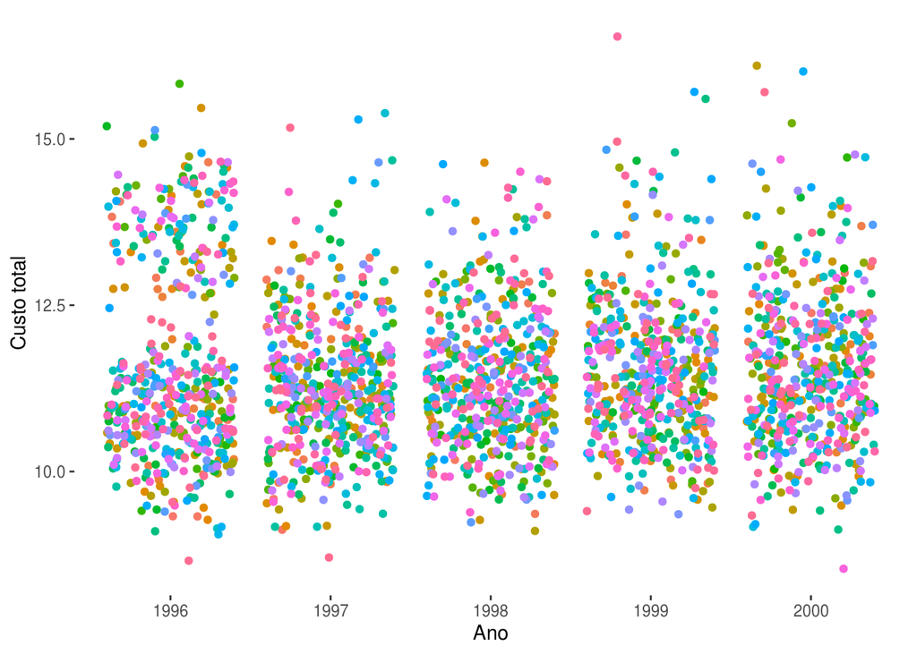

# Estimativas

## Modelo pooled (ou OLS)

```r
reg1 <- plm(C ~ W1 + W2 + W3 + W4 + T,
            data = dados,
            model = "pooling",
            index = c("BANK", "Year"))
```

Podemos visualizar o resultado utilizando o *stargazer* novamente:

```r
stargazer(reg1, type = "html")
```

|  | *Dependent variable:* |
| --- | --- |
|  | C |
| W1 | 1.100*** |
|  | (0.069) |
| W2 | -0.271*** |
|  | (0.031) |
| W3 | 0.341*** |
|  | (0.060) |
| W4 | -0.055 |
|  | (0.047) |
| T | 0.052*** |
|  | (0.015) |
| Constant | 4.448*** |
|  | (0.462) |
| Observations | 2,470 |
| R<sup>2</sup> | 0.267 |
| Adjusted R<sup>2</sup> | 0.265 |
| F Statistic | 179.183*** (df = 5; 2464) |
| *Note:* | p<0.1; p<0.05; p<0.01 |

### Testando a presença de heterocedasticidade

Inicialmente podemos fazer uma inspeção visual, fazendo um gráfico dos resíduos estimados em função dos valores estimados:

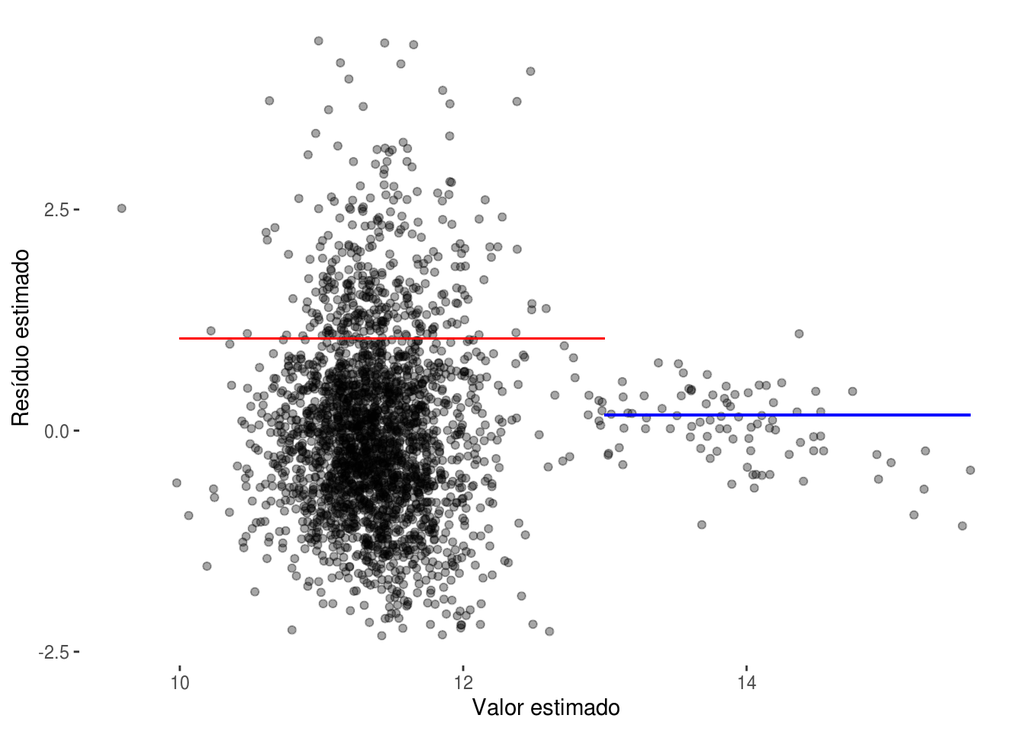

De fato parece haver uma maior variabilidade nos resíduos quando os valores estimados da variável dependente se encontram entre $10$ e $13$ se comparado àqueles vistos quando os valores são maiores do que $13$ (as linhas horizontais representam as variâncias amostrais de cada grupo de resíduos).

Para obtermos um resultado mais formal, utilizaremos o teste de Breusch-Pagan:

```r
bptest(reg1, studentize = F)
```

```
##
##  Breusch-Pagan test
##
## data:  reg1
## BP = 45.933, df = 5, p-value = 9.37e-09
```

Rejeitamos a hipótese nula de homocedasticidade, indicando a necessidade de uma matriz de covariância robusta. Ela pode ser obtida utilizando o comando *coeftest* da biblioteca *lmtest* em conjunto com a biblioteca *sandwich*:

```r
coeftest(reg1, vcovHC)
```

```
##
## t test of coefficients:
##
##              Estimate Std. Error t value  Pr(>|t|)
## (Intercept)  4.447729   0.530395  8.3857 < 2.2e-16 ***
## W1           1.099830   0.078317 14.0432 < 2.2e-16 ***
## W2          -0.270872   0.032094 -8.4400 < 2.2e-16 ***
## W3           0.340946   0.076432  4.4608 8.532e-06 ***
## W4          -0.054545   0.070743 -0.7710 0.4407636
## T            0.051901   0.015495  3.3494 0.0008219 ***
## ---
## Signif. codes:  0 '***' 0.001 '**' 0.01 '*' 0.05 '.' 0.1 ' ' 1
```

Veja que apesar da presença da heterocedasticidade, o uso de uma matriz de covariância robusta não alterou a significância de nenhuma das variáveis.

## Modelo de efeitos fixos

```r
reg2 <- plm(C ~ W1 + W2 + W3 + W4 + T,
            data = dados,
            model = "within",
            index = c("BANK", "Year"))
```

Comparando as duas estimativas (assumindo homocedasticidade, por simplicidade):

```r
stargazer(reg1, reg2, type = "html")
```

|  | *Dependent variable:* |  |
| --- | --- | --- |
|  | C |  |
|  | (1) | (2) |
| W1 | 1.100*** | 1.166*** |
|  | (0.069) | (0.076) |
| W2 | -0.271*** | -0.285*** |
|  | (0.031) | (0.035) |
| W3 | 0.341*** | 0.297*** |
|  | (0.060) | (0.067) |
| W4 | -0.055 | -0.072 |
|  | (0.047) | (0.053) |
| T | 0.052*** | 0.049*** |
|  | (0.015) | (0.015) |
| Constant | 4.448*** |  |
|  | (0.462) |  |
| Observations | 2,470 | 2,470 |
| R<sup>2</sup> | 0.267 | 0.277 |
| Adjusted R<sup>2</sup> | 0.265 | 0.094 |
| F Statistic | 179.183*** (df = 5; 2464) | 151.134*** (df = 5; 1971) |
| *Note:* | p<0.1; p<0.05; p<0.01 |  |

### OLS x Efeitos fixos

Para isso, é feito um teste *F* de significância global para os coeficientes de efeitos fixos individuais.

```r
pFtest(reg2, reg1)
```

```
##
##  F test for individual effects
##
## data:  C ~ W1 + W2 + W3 + W4 + T
## F = 1.03, df1 = 493, df2 = 1971, p-value = 0.3334
## alternative hypothesis: significant effects
```

Não rejeitamos a hipótese nula de que OLS é melhor que efeitos fixos (coeficientes não significativos).

## Modelo de efeitos aleatórios

```r
reg3 <- plm(C ~ W1 + W2 + W3 + W4 + T,
            data = dados,
            model = "random",
            index = c("BANK", "Year"))
```

Comparando as estimativas dos três modelos:

```r
stargazer(reg1, reg2, reg3, type = "html")
```

|  | *Dependent variable:* |  |  |
| --- | --- | --- | --- |
|  | C |  |  |
|  | (1) | (2) | (3) |
| W1 | 1.100*** | 1.166*** | 1.101*** |
|  | (0.069) | (0.076) | (0.069) |
| W2 | -0.271*** | -0.285*** | -0.271*** |
|  | (0.031) | (0.035) | (0.031) |
| W3 | 0.341*** | 0.297*** | 0.340*** |
|  | (0.060) | (0.067) | (0.060) |
| W4 | -0.055 | -0.072 | -0.055 |
|  | (0.047) | (0.053) | (0.047) |
| T | 0.052*** | 0.049*** | 0.052*** |
|  | (0.015) | (0.015) | (0.015) |
| Constant | 4.448*** |  | 4.438*** |
|  | (0.462) |  | (0.462) |
| Observations | 2,470 | 2,470 | 2,470 |
| R<sup>2</sup> | 0.267 | 0.277 | 0.267 |
| Adjusted R<sup>2</sup> | 0.265 | 0.094 | 0.265 |
| F Statistic | 179.183*** (df = 5; 2464) | 151.134*** (df = 5; 1971) | 896.975*** |
| *Note:* | p<0.1; p<0.05; p<0.01 |  |  |

De fato as estimativas são muito similares, o que é um indício de que não há necessidade de fazer uso de técnicas de estimação para dados em painel.

### OLS x Efeitos aleatórios

Para isso testamos se há heterogeneidade entre as variâncias dos indivíduos, sendo a hipótese nula de que não há variabilidade (não há um ‘efeito-painel’).

```r
plmtest(reg1, type = "bp")
```

```
##
##  Lagrange Multiplier Test - (Breusch-Pagan) for balanced panels
##
## data:  C ~ W1 + W2 + W3 + W4 + T
## chisq = 0.15398, df = 1, p-value = 0.6948
## alternative hypothesis: significant effects
```

Não rejeitamos a hipótese nula de que OLS é a melhor opção quando comparado ao modelo de efeitos aleatórios.

### Efeitos fixos x Efeitos aleatórios

Para isso utilizamos o teste de Hausman, que basicamente testa se os termos de erros são correlacionados com os regressores, com sua hipótese nula sendo de que não são. Se a rejeitarmos, temos indícios de que o modelo preferido é o de efeitos fixos.

```r
phtest(reg2, reg3)
```

```
##
##  Hausman Test
##
## data:  C ~ W1 + W2 + W3 + W4 + T
## chisq = 4.5272, df = 5, p-value = 0.4763
## alternative hypothesis: one model is inconsistent
```

Não rejeitamos a nula de que o modelo de efeitos aleatórios é preferido.

[^1]: Uma análise mais completa do banco de dados pode ser vista em Banks Study